# Question 2

STAT3017/STAT6017 - Assignment 2

Songze Yang u7192786

```r
knitr::opts_chunk$set(echo = TRUE)
library(mvnfast)
library(future.apply)
```

```r
library(ggplot2)
```

# Question 2

In this question we consider the empirical spectral density (ESD) of large matrices with entries that are given by independent identically distributed random variables with zero mean and variance equal to $1$. The steps you will take are:

1. Simulate $n$ = $500$ matrices $X_n$ of size $p \times p$ where $p$ = $100$ with entries sampled from the standard Normal distribution. Calculate the eigenvalues of each of the matrices $\frac{X_n}{\sqrt{n}}$ and plot the location of the eigenvalues together (i.e., obtained from all the matrices) on the complex plane.

Firstly, let’s write a function to simulation a $p \times p$ square matrix with Gaussian entries.

```r
randn_mat<-function(p = p, mu = mu, sigma = sigma){
  matrix(rmvn(p * p, mu = mu, sigma = sigma), p, p)
}
```

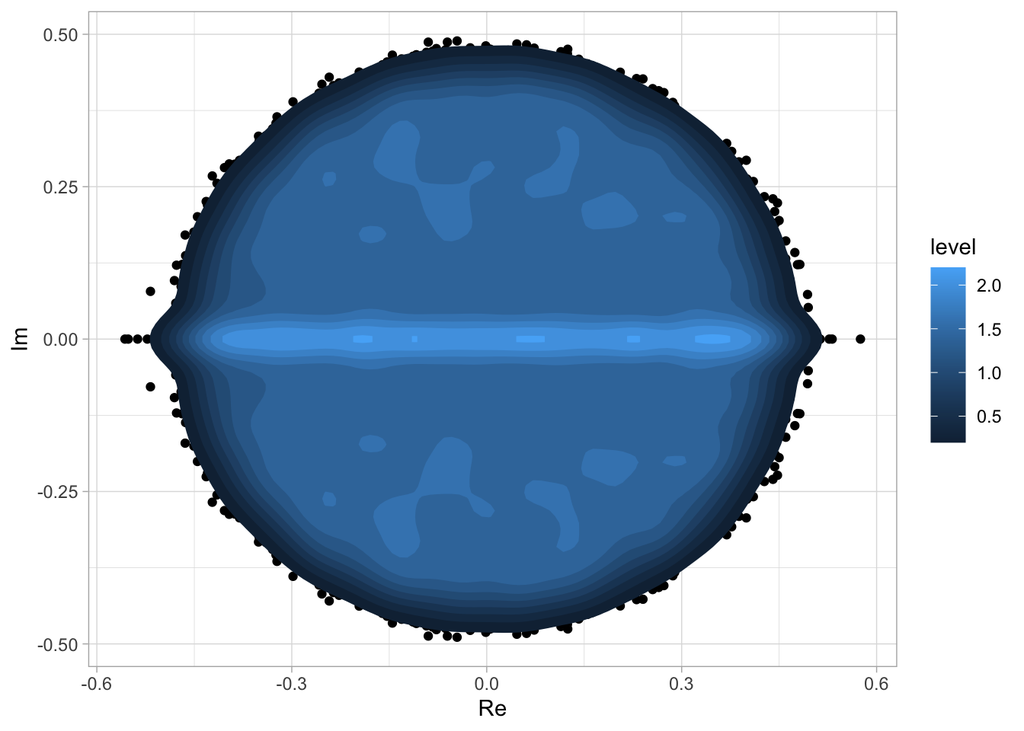

```r
plan(multisession, workers = 8)

n = 500
p = 100
mu = 0
sigma = 1
Lambdas = replicate(n, {
  X = randn_mat(p, mu, sigma)
  eigen(X/sqrt(n), only.values = TRUE)$values
})

df <- as.data.frame(cbind(c(Re(Lambdas)), c(Im(Lambdas))))
names(df) <- c("Re", "Im")
distance <- sqrt(df$Re^2 + df$Im^2)

df$distance <- distance

ggplot(df, aes(x = Re, y = Im)) +
  geom_point()+
  stat_density_2d(aes(fill = ..level..), geom = "polygon")+
  theme_light()
```

```r
#plot(x = df$Re, y = df$Im, col = "blue", cex = 0.1, xlab = "Real axis", ylab = "Comlex axis")
```

2. Comment on the distribution of the eigenvalues.

Based on the distribution of eigenvalues, it is evident that they primarily form a circular pattern. The eigenvalues are roughly distributed across the range of $-0.5$ to $0.5$ along both the real and complex axes. However, it’s noticeable that the outer boundary of this distribution is somewhat uneven. This unevenness could potentially be attributed to the limited sample size, as larger samples often yield smoother distributions. From the density estimation, the eigenvalues now are not evenly distributed and scatter around the real axis and a number of areas outside the real line.

3. Repeat part (a), this time with variance larger than $1$, what do you notice?

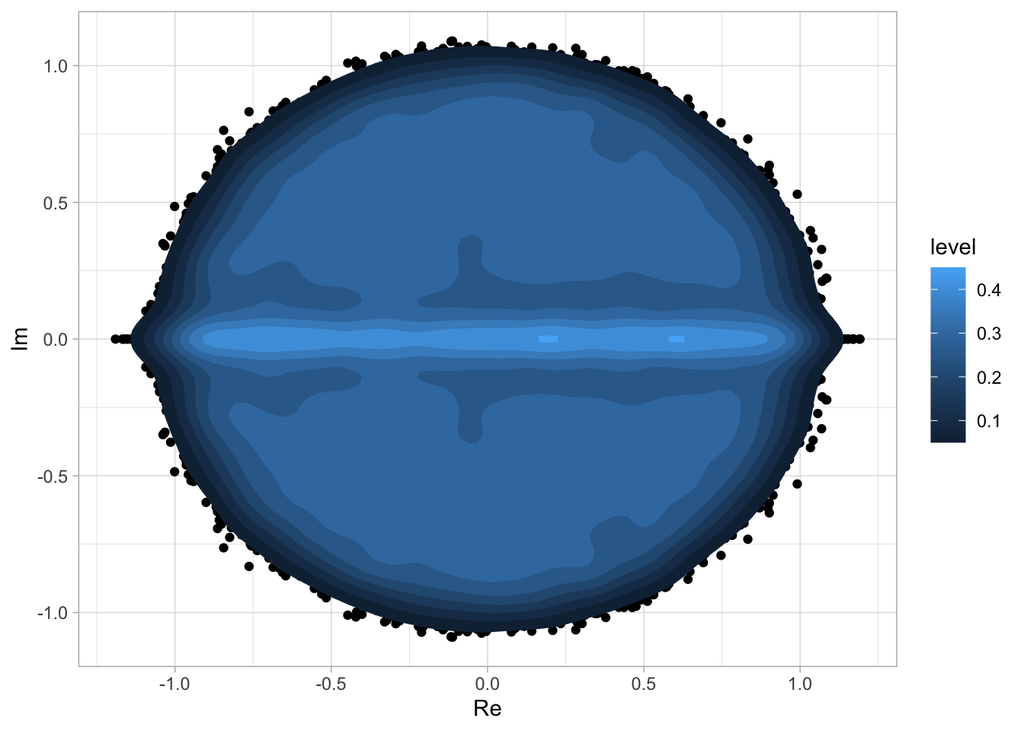

```r
plan(multisession, workers = 8)

n = 500
p = 100
mu = 0
sigma = 5
Lambdas = replicate(n, {
  X = randn_mat(p, mu, sigma)
  eigen(X/sqrt(n), only.values = TRUE)$values
})

df <- as.data.frame(cbind(c(Re(Lambdas)), c(Im(Lambdas))))
names(df) <- c("Re", "Im")
distance <- sqrt(df$Re^2 + df$Im^2)

df$distance <- distance

ggplot(df, aes(x = Re, y = Im)) +
  geom_point()+
  stat_density_2d(aes(fill = ..level..), geom = "polygon")+
  theme_light()
```

```r
#plot(x = df$Re, y = df$Im, col = "blue", cex = 0.1, xlab = "Real axis", ylab = "Comlex axis")
```

4. Repeat the experiment three times with $p$ and $n$ larger and larger with the ratio $p/n$ fixed. What do you observe?

Let’s choose a random overparameterization ratio $p/n$, denoted $\gamma$, as $0.2$ and increase $n$ to be $1000$, $2000$ and $3000$.

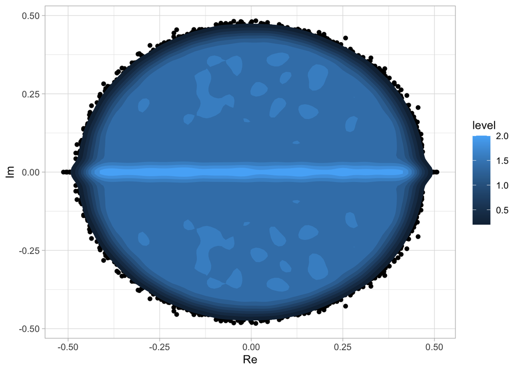

```r
plan(multisession, workers = 8)

gamma = 0.2
n = 1000
p = n * gamma
mu = 0
sigma = 1
Lambdas = replicate(n, {
  X = randn_mat(p, mu, sigma)
  eigen(X/sqrt(n), only.values = TRUE)$values
})

df <- as.data.frame(cbind(c(Re(Lambdas)), c(Im(Lambdas))))
names(df) <- c("Re", "Im")
distance <- sqrt(df$Re^2 + df$Im^2)

df$distance <- distance

ggplot(df, aes(x = Re, y = Im, )) +
  geom_point()+
  stat_density_2d(aes(fill = ..level..), geom = "polygon")+
  theme_light()
```

```r
#plot(x = df$Re, y = df$Im, col = "blue", cex = 0.1, xlab = "Real axis", ylab = "Comlex axis")
```

The visualization is similar to what we get in part $(a)$, but the edge now looks smoother. Let’s increase to $n = 2000$ and $p = 400$.

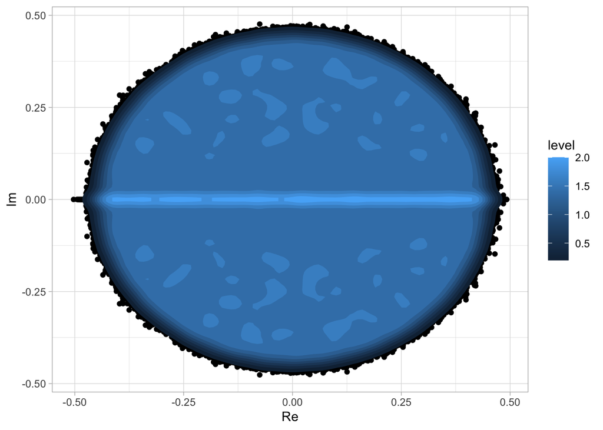

```r
plan(multisession, workers = 8)

gamma = 0.2
n = 2000
p = n * gamma
mu = 0
sigma = 1
Lambdas = replicate(n, {
  X = randn_mat(p, mu, sigma)
  eigen(X/sqrt(n), only.values = TRUE)$values
})

df <- as.data.frame(cbind(c(Re(Lambdas)), c(Im(Lambdas))))
names(df) <- c("Re", "Im")
distance <- sqrt(df$Re^2 + df$Im^2)

df$distance <- distance

ggplot(df, aes(x = Re, y = Im)) +
  geom_point()+
  stat_density_2d(aes(fill = ..level..), geom = "polygon")+
  theme_light()
```

```r
#plot(x = df$Re, y = df$Im, col = "blue", cex = 0.1, xlab = "Real axis", ylab = "Comlex axis")
```

As $n$ and $p$ both get larger, the plot becomes smoother on the same support. Let’s increase to $n = 3000$ and $p = 600$.

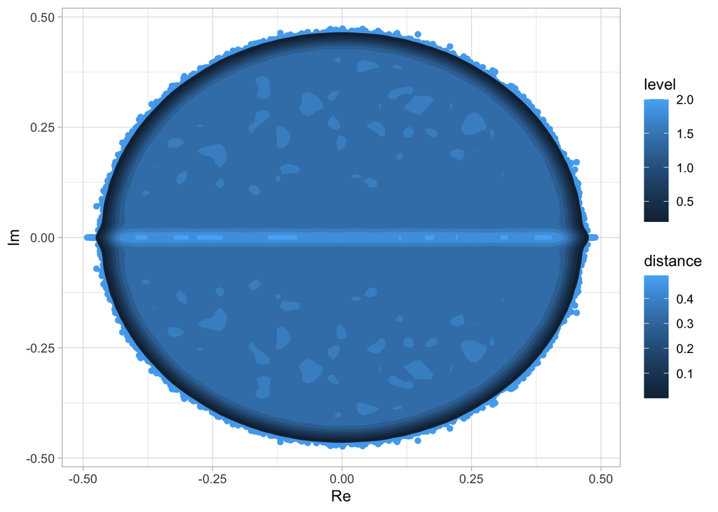

```r
plan(multisession, workers = 8)

gamma = 0.2
n = 3000
p = n * gamma
mu = 0
sigma = 1
Lambdas = replicate(n, {
  X = randn_mat(p, mu, sigma)
  eigen(X/sqrt(n), only.values = TRUE)$values
})

df <- as.data.frame(cbind(c(Re(Lambdas)), c(Im(Lambdas))))
names(df) <- c("Re", "Im")
distance <- sqrt(df$Re^2 + df$Im^2)

df$distance <- distance

ggplot(df, aes(x = Re, y = Im, colour = distance)) +
  geom_point()+
  stat_density_2d(aes(fill = ..level..), geom = "polygon")+
  theme_light()
```

```r
#plot(x = df$Re, y = df$Im, col = "blue", cex = 0.1, xlab = "Real axis", ylab = "Comlex axis")
```

Last graph is the smoothest among all in terms of the density and also the boundary, indicating the distribution is increasingly smooth as the $n,p \rightarrow \infty$ and $p/n \rightarrow \gamma$.

5. Now, repeat the experiment with the entries sampled from a Student $T$ distribution with parameter $1 < \nu \le 2$. What do you observe and what can you conclude?

Let’s write a function to generate a random matrices with student $T$-distributed entries and plot their eigenvalues together.

```r
randt_mat<- function(p = p, nu = nu){
  matrix(rt(p * p, df = nu), p, p)
}
```

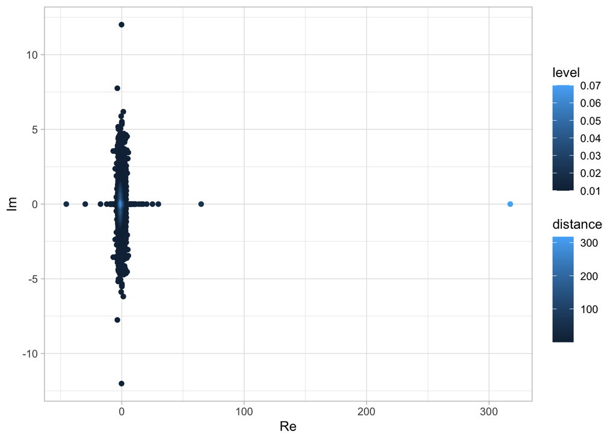

```r
plan(multisession, workers = 8)

n = 500
p = 100
nu = 1.5
Lambdas = replicate(n, {
  X = randt_mat(p, nu)
  eigen(X/sqrt(n), only.values = TRUE)$values
})

df <- as.data.frame(cbind(c(Re(Lambdas)), c(Im(Lambdas))))
names(df) <- c("Re", "Im")
distance <- sqrt(df$Re^2 + df$Im^2)

df$distance <- distance

ggplot(df, aes(x = Re, y = Im, colour = distance)) +
  geom_point()+
  stat_density_2d(aes(fill = ..level..), geom = "polygon")+
  theme_light()
```

```r
#plot(x = df$Re, y = df$Im, col = "blue", cex = 0.1, xlab = "Real axis", ylab = "Comlex axis")
```

The graph below shows a novel pattern. The eigenvalues of a $T$-distributed entries random matrix are not bounded in a closed region and we can observe a number of very large entry from both axes.

The student t-distribution with $\nu \in (1,2]$ has variance that equals to infinity. Thus, it is reasonable to conclude that the eigenvalues distribution of random matrix depends on the variance of each entry in the matrix. In other words, it depends on the lower moments (first and second moments of the probability distribution function) in the regular condition (finite fourth moment).

6. Why don’t you get a Wigner semi-circle distribution? Why don’t you get a Marchenko- Pastur distribution for the limiting spectral distribution?

We encounter the Wigner semi-circle distribution in tutorial 2, where we simulate a number of large symmetric matrix and compute the eigenvalue based on the symmetric matrix. From results of linear algebra, the symmetric matrix has real eigenvalues. So we can plot the eigenvalues on the real line only.

In lecture, when we derive the Marchenko-Pastur distribution, we derive in respect to the sample covariance matrix, which is positive definite or positive semi-definite as the covariance is the product of two data matrices with real entries. Because of this, the eigenvalue of the sample covariance matrix is greater than or equal to 0.

However, here we have not assumed these properties for our simulated matrix. Therefore, our matrix has both real and complex values. Thus, we could not recover the Wigner semi-circle distribution and the Marchenko- Pastur distribution.